# Nanual_exercise6

```python
# Importing necessary packages
import pandas as pd
from sklearn.model_selection import train_test_split
import random
from numpy import sqrt, abs, round
from scipy.stats import norm
from statistics import stdev
```

```python
# Importing the 'Adult' data set
adult = pd.read_csv('C:/Users/Default.DESKTOP-7BESS1K/Desktop/Adult')
adult
```

|  | age | workclass | demogweight | education | education-num | marital-status | occupation | relationship | race | sex | capital-gain | capital-loss | hours-per-week | native-country | income |
| --- | --- | --- | --- | --- | --- | --- | --- | --- | --- | --- | --- | --- | --- | --- | --- |
| 0 | 39 | State-gov | 77516 | Bachelors | 13 | Never-married | Adm-clerical | Not-in-family | White | Male | 2174 | 0 | 40 | United-States | <=50K. |
| 1 | 50 | Self-emp-not-inc | 83311 | Bachelors | 13 | Married-civ-spouse | Exec-managerial | Husband | White | Male | 0 | 0 | 13 | United-States | <=50K. |
| 2 | 38 | Private | 215646 | HS-grad | 9 | Divorced | Handlers-cleaners | Not-in-family | White | Male | 0 | 0 | 40 | United-States | <=50K. |
| 3 | 53 | Private | 234721 | 11th | 7 | Married-civ-spouse | Handlers-cleaners | Husband | Black | Male | 0 | 0 | 40 | United-States | <=50K. |
| 4 | 28 | Private | 338409 | Bachelors | 13 | Married-civ-spouse | Prof-specialty | Wife | Black | Female | 0 | 0 | 40 | Cuba | <=50K. |
| ... | ... | ... | ... | ... | ... | ... | ... | ... | ... | ... | ... | ... | ... | ... | ... |
| 24995 | 41 | Private | 112507 | 10th | 6 | Married-civ-spouse | Transport-moving | Husband | White | Male | 0 | 0 | 60 | United-States | <=50K. |
| 24996 | 19 | Private | 236940 | HS-grad | 9 | Never-married | Farming-fishing | Own-child | White | Male | 0 | 0 | 40 | United-States | <=50K. |
| 24997 | 33 | Private | 278514 | HS-grad | 9 | Divorced | Craft-repair | Own-child | White | Female | 0 | 0 | 42 | United-States | <=50K. |
| 24998 | 21 | ? | 433330 | Some-college | 10 | Never-married | ? | Unmarried | White | Male | 0 | 0 | 40 | United-States | <=50K. |
| 24999 | 25 | Private | 258379 | Bachelors | 13 | Married-civ-spouse | Prof-specialty | Wife | White | Female | 0 | 0 | 32 | United-States | <=50K. |

25000 rows × 15 columns

1. Partition the data set so that 50% of the records are included in the training data set and 50% are included in the test data set. Use a bar graph to confirm your proportions.

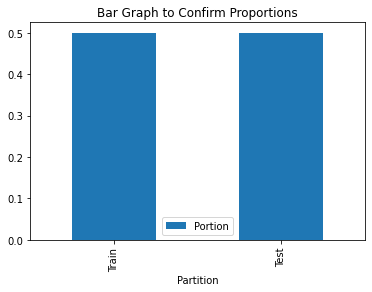

```python
# Creating partition values in a data frame.
adult_train, adult_test = train_test_split(adult, test_size =0.5, random_state = 7)

# Collecting proportion values in a data frame.
df = pd.DataFrame({'Partition':['Train','Test'],
                   'Portion':[(adult_train.shape[0]/adult.shape[0]),
                              (adult_test.shape[0]/adult.shape[0])]})

# Creating a bar plot.
df.set_index('Partition').plot(kind='bar', title='Bar Graph to Confirm Proportions')
```

2. Identify the total number of records in the training data set, and how many records in the training data set have an income value of >50 K.

```python
# Identifying the total number of records in the training data set
total_records = adult_train.shape[0]

# Identifying the number of records in the training data set that have an income value of more than 50,000.
greaterthan50k_records = adult_train.loc[adult_train['income']=='>50K.'].shape[0]

# Printing the results
print(records, '-- Total number of records in the training data set:')
print(records_2,'--- Number of records in the training data set with an income of more than 50k', )
```

[output not shown]

3. Use your answers from the previous exercise to calculate how many records with income >50 K you need to resample in order to have 35% of the rebalanced data set have incomes of >50 K.

```python
# Determine the portion size to resample
(0.35 * total_records - greaterthan50k_records) / 0.65
```

```
2144.6153846153848
```

4. Perform the rebalancing described in the previous exercise and confirm that 35% of the records in the rebalanced data set have incomes >50 K.

```python
# Subsetting the records to resample
records_toresample = adult_train.loc[adult_train['income']=='>50K.']

# Resampling the 50k records to determine the sample size
resample = records_toresample.sample(n = 2145, replace=True)

# Concatenating the sampled data with the rest of the traning data to rebalance
rebal_adult_train = pd.concat([adult_train, resample])

# Getting the table proportion of income classes in the training data
rebal_adult_train['income'].value_counts() / rebal_adult_train.shape[0]
```

```
<=50K.    0.649983
>50K.     0.350017
Name: income, dtype: float64
```

5. Validate your partition by performing a two‐sample Z‐test for the difference in means for the mean age in the training set versus the mean age in the test set.

```python
# Validating the partition by performing two sample z-tests
n1 = adult_train.shape[0]
x1 = adult_train['age'].mean()
sd1 = stdev(adult_train['age'])

n2 = adult_test.shape[0]
x2 = adult_test['age'].mean()
sd2 = stdev(adult_test['age'])

# Calculating the denominator pooled standard error
pooled = sqrt(((sd1 ** 2) / n1) + ((sd2 ** 2) / n2))

# Calculate the z-value
z_value = round(((x1 - x2) - 0) / pooled, 6)

# Calculating the p-value
p_value = round(2 * (1 - norm.cdf(abs(z))), 6)

# Printing the results
print('z-value:', z_value)
print('p-value:', p_value)
```

```
z-value: 0.039274
p-value: 0.968672
```

6. Validate your partition by performing a two‐sample Z‐test for the difference in proportions for the proportion of >50 K records in the training set versus the proportion of >50 K records in the test set.

```python
# Validating the partition by performing two sample z-tests
n11 = adult_train.shape[0]
x11 = adult_train.loc[adult_train['income']=='>50K.'].shape[0]
p11 = x11 / n11

n21 = adult_test.shape[0]
x22 = adult_test.loc[adult_test['income']=='>50K.'].shape[0]
p22 = x22 / n21

p = (x11 + x22) / (n11 + n21)

# Calculating the z-value
z_value2 = round(((p11 - p22) - 0) / sqrt(p * (1 - p) * ((1 / n11) + (1 / n21))), 6)

# Calculating the p-value
p_value2 = round(2 * (1 - norm.cdf(abs(z_value2))), 6)

# Printing the results
print('z-value:', z_value2)
print('p-value:', p_value2)
```

```
z-value: -0.32609
p-value: 0.744356
```